# Machine Learning and Wave Farms

Sam Bryan

2024-12-15

# Introduction

```
Energy comes in many different forms, and being able to harness it in a sustainable way has major implications across all fields. In recent years new technology has emerged from engineering and physics to utilize wave energy in the ocean. This in theory, and in practice actually makes a lot of sense…
```

### Data

```
The data set I am utilizing is from a wave farm in Perth, Australia. The data contains  49 different WECs in over thirty-thousand different configurations. In order to understand what this is, it’s best to think of each WEC as a buoy in the ocean. Each WEC has a coordinate (latitude, longitude) base…
```

```
## # A tibble: 1 × 149
##      X1    Y1    X2    Y2    X3    Y3    X4    Y4    X5    Y5    X6    Y6    X7
##   <dbl> <dbl> <dbl> <dbl> <dbl> <dbl> <dbl> <dbl> <dbl> <dbl> <dbl> <dbl> <dbl>
## 1     0     0   200     0   300     0   400     0   550     0   750     0   850
## # ℹ 136 more variables: Y7 <dbl>, X8 <dbl>, Y8 <dbl>, X9 <dbl>, Y9 <dbl>,
## #   X10 <dbl>, Y10 <dbl>, X11 <dbl>, Y11 <dbl>, X12 <dbl>, Y12 <dbl>,
## #   X13 <dbl>, Y13 <dbl>, X14 <dbl>, Y14 <dbl>, X15 <dbl>, Y15 <dbl>,
## #   X16 <dbl>, Y16 <dbl>, X17 <dbl>, Y17 <dbl>, X18 <dbl>, Y18 <dbl>,
## #   X19 <dbl>, Y19 <dbl>, X20 <dbl>, Y20 <dbl>, X21 <dbl>, Y21 <dbl>,
## #   X22 <dbl>, Y22 <dbl>, X23 <dbl>, Y23 <dbl>, X24 <dbl>, Y24 <dbl>,
## #   X25 <dbl>, Y25 <dbl>, X26 <dbl>, Y26 <dbl>, X27 <dbl>, Y27 <dbl>, …
```

Each row, like the one above, contains longitude and latitude information for each individual buoy. The format for power is very similar in the sense that each set of longitude & latitude has a specific power output. In total there are 149 columns, however, we won’t use all of these throughout the analysis.

### Preliminary Analysis & sams_metric

```
A preliminary analysis involved Hierarchical clustering, which essentially groups configurations of WECs with similar characteristics. “Similar Characteristics” is quantified by the distance between data points. Using tuning parameters such as the amount of clusters (k-value), k = 3 was optimal for …

Based on this information I had to engineer a feature that would best capture information about which configuration of 49 WECs would result in a higher power output. Although this seemed like a solely mathematics-based problem, the solution involved statistical methods.  We know that the highest pow…

    With this understanding, I implemented a loop which would apply the outlined steps for every single configuration in the data. The loop outputs an average slope value for each of the thirty-six thousand configurations. This gives the supervised learning algorithms another variable to use and tra…
```

```r
metric_vector <- NULL
threshold <- 5

sams_metric_table <- data.frame(
  iteration = integer(),
  metric = numeric(),
  stringsAsFactors = FALSE
)

for(i in 1:36043){

  data_for_clustering <- wave_farm |>
    select(-qW, -contains("power")) |>
    mutate(config = row_number()) |>
    pivot_longer(-config,
                 names_to = c("coord", "buoy"),
                 names_pattern =
                   "(X|Y)([0-9]+)") |>
    pivot_wider(
      names_from = coord,
      values_from = value,
      id_cols = c(config, buoy)) |>
    filter(config == i) |>
    na.omit()

  clustering <- data_for_clustering |>
    dist() |>
    hclust(method = "single")

  valid_clusters <- data_for_clustering |>
    mutate(my_clusters = cutree(clustering, k = 6)) |>
    count(my_clusters) |>
    filter(n >= threshold) |>
    pull(my_clusters)


  metric_vector[i] <- data_for_clustering |>
    mutate(my_clusters = cutree(clustering, k = 6)) |>
    filter(my_clusters %in% valid_clusters) |>
    group_by(my_clusters) |>
    summarize(slope = round(lm(Y~X)$coef[2], 3))|>
    summarize(mean = mean(slope, na.rm = T)) |>
    pull(mean)

  sams_metric_table <- rbind(
    sams_metric_table,
    data.frame(config = i, metric = metric_vector[i])
  )

  print(i)
}

sams_metric_table

sams_metric <- metric_vector[i]
```

```
The next step was to implement sams_metric into the wave_farm data set as a new column. This allows us to use it as a predictor of total power output in a supervised learning algorithm.
```

### Three Cases

Three cases: Slopes close to zero, Positive slope, Negative slope

The three different cases represent the most common configurations of buoys. Preliminary analysis revealed that on average case 3 had the highest average power output. In terms of feature engineering with sams_metric, we found out how to quantify this configuration of points so that a machine learning algorithm would have an additional variable outside of just longitude & latitude.

First Case: slope close to zero

ex slope = 0.0006666667 (configuration 15450)

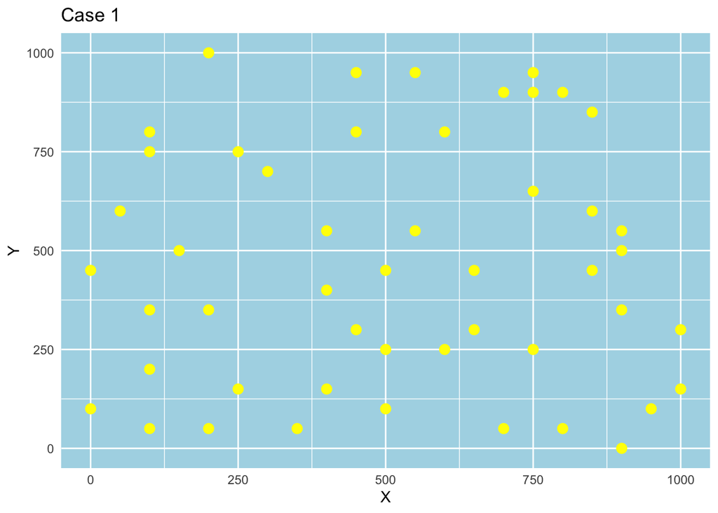

It’s convenient to think about each yellow dot as a buoy in the ocean. Case one has a scattered format, the buoy placement does not seem very intentional.

Case 2

positive slope = 2.011667

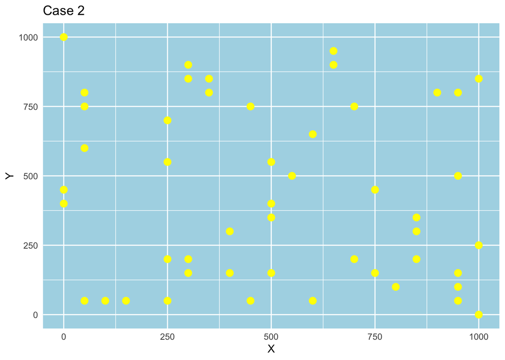

Case 2 is a little more defined than the first. In this example, there’s are a few clusters of points that have a positive gradient. Sams_metric picked picked up on these clusters which shifted the average slope higher.

Case 3 slope = -0.882 (configuration 6)

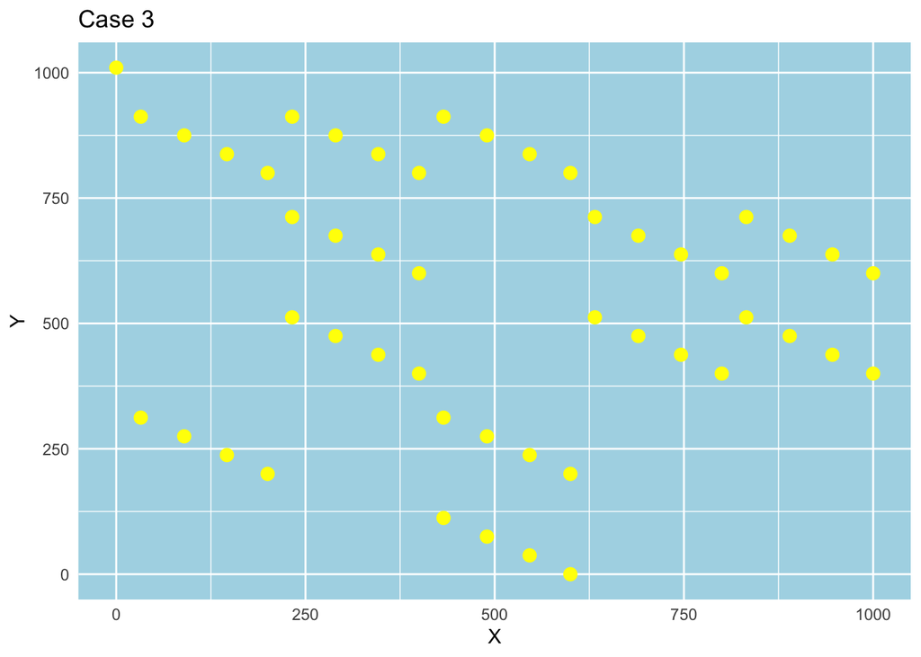

Case 3 has clusters with defined linear gradients. For the majority of the data set, this was the configuration that produced the highest total power output.

# Random Forest Algorithm

In order to understand how well sams_metric is actually capturing information about total_power, I conducted a Random Forest Algorithm. To proceed with the random forest, we have to create a subset of the original data that does not contain any columns directly related to power, since our model would just “cheat” off of these columns. The wave_farm_rf subset only contains information about longitude, Latitude, and sams_metric. The Random Forest revealed that sams_metric was one of the most important variables for predicting total power output for a given configuration. That being said, there were a few upper and lower latitude coordinates that were ranked as most important.

```r
library(ranger)

rf_model_2 <- ranger( Total_Power ~ .,
  data = wave_farm_rf,
  importance = "permutation",
  num.trees = 500
)
```

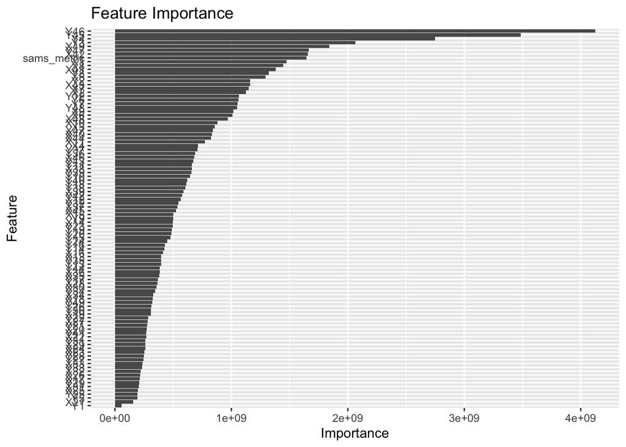

It’s worth mentioning that that there were a few Latitudes that were surprisingly important for predicting total power. The variable importance graph doesn’t tell us about the context of the variable importance, meaning that we don’t know if the highly important latitude points are indicative of lower or higher total power output. I decided that this was worth a brief analysis.

#### Looking at the lower bound feature importance (latitude 3)

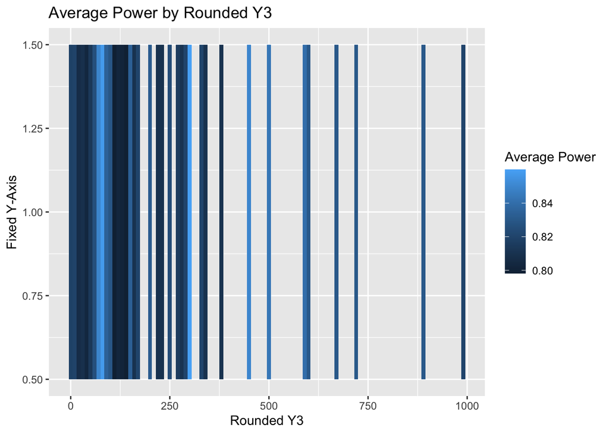

Y3 simply corresponds to the latitude of the third WEC or Bouy in each of the possible configurations. The rounded latitude represents the range of latitudes present in each configuration of Bouy 3.

### Looking at the upper bound lattitude of feature importance

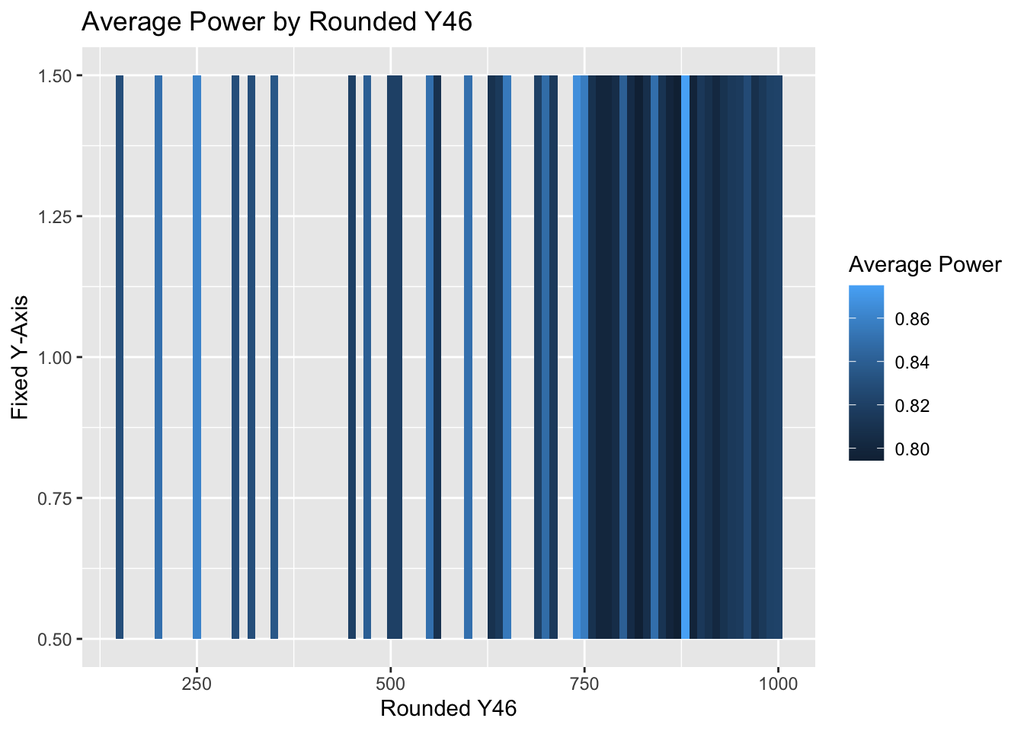

Similar logic for the upper bound of latitude Y46, which corresponds to the latitude of the 46th WEC or Buoy in each of the possible configurations. The rounded latitude represents the range of latitudes present in each configuration of Buoy 46. This visualization suggests that generally speaking, the distribution of average power is more bimodal.

The random forest outputs information about variable importance in the context of how much taking a variable out of the data set would reduce the overall predictive power. The fact that lower latitudes and higher latitudes are the most important variables based on the random forest algorithm, likely has to do with the fact that the first and last latitudes are largely indicative of the overall configuration of buoys.

# Supervised learning analysis: Neural Network model

```
I proceed with the Neural Network model with the goal of predicting total_power given coordinates (longitude, latitude) and sams_metric.
```

The general idea behind a supervised learning Neural Network is that we can weigh different combinations of features (variables) within a neuron, and use a specific function on a sum of those features and weights, which allows us to capture non-linear relationships and ultimately predict total power for a given configuration. We can adjust the number of neurons depending on the complexity of our data. In my case, we were limited to just nine neurons, which could have led to model bias. The Neural Network algorithm can be divided into three main layers, the input layer, the hidden layer, and the output layer. Part of what makes the neural network so powerful is that each neuron performs a similar operation, independently of another. Each neuron has unique weights and biases which allows them to “learn” from each other. For example, one neuron might focus on weights where the longitude and latitude inputs carry the greatest contribution to power, while another neuron might extract configurations where sams_metric dominates total power. Another Neuron might capture information about how sams_metric and the latitude affect total power. This is a relatively elementary introduction to the input layer. The hidden layer is a little more complicated because it encodes information from all the neurons in the input layer. Each neuron has an activation depending on the configuration. We can think of this activation on a scale from zero to one, in the sense that for a given configuration a neuron might fire strongly (activate) if the buoys are spaced in a linear fashion. In theory, more neurons allow us to express more interactions between the three features. That being said, we don’t want to overfit the data. In the context of my data set, twenty would’ve been a more ideal number of neurons. I claim this based on the idea that we can capture more weighted combinations with more neurons. The third and final layer of the neural network is the output layer. The output layer builds off the hidden layer by calculating the weighted sum of all the activated neurons. This might look like Total Power Prediction =woh1+w1h2+⋯+w9h9+bo. Again, this just aims to calculate a single output, corresponding to the total power output.

A visual representation of this may be helpful. The first neuron operation would look something like this. hi=f(wi1X+wi2Y+wi3Sams_Metric+bi), wi1, wi2, wi3 are the weights, bi is the bias, and f is the activation function. W is simply a weight that is multiplied by each feature. In essence, the weights assigned to each feature tell us about its overall importance for a given neuron. Bias is simply a parameter that allows each neuron to shift the activation function which can help it pick up on patterns more effectively. The default activation function is a sigmoid, which basically tells us how positive a weighted sum is. We can manipulate the activation function by adding a specific bias.

```r
library(dplyr)
library(nnet)

set.seed(1)
train_index <- sample(1:nrow(wave_farm_rf), 0.8 * nrow(wave_farm_rf))
train_data <- wave_farm_rf[train_index, ]
test_data <- wave_farm_rf[-train_index, ]

train_data <- train_data |>
  mutate(across(-Total_Power, ~ (.-mean(.))/sd(.)))

test_data <- test_data |>
  mutate(across(-Total_Power, ~ (.-mean(.))/sd(.)))

nn_model <- nnet(
  Total_Power ~ .,
  data = train_data,
  size = 9,
  linout = TRUE,
  maxit = 500,
  decay = 0.01,
  trace = FALSE
)

predictions <- predict(nn_model, test_data)
```

Specifically focusing on my implantation, three main parameters were useful. The number of neurons, which is denoted as “size”, was restricted by the specific implementation I was using. I would’ve preferred to use a larger number of neurons, especially based on my results, which I’ll discuss in the next paragraph. The second parameter was Maxit, which doesn’t actually correspond to a specific layer outlined above. Maxit simply sets a cap on the number of attempts the neural network is allowed to make to refine itself throughout the training process. In a sense, we can relate it to the output layer as to how many times the weights and bias within the hidden layer can be adjusted and re-calculated. I used a Maxit value of 500, which is reasonable given the size of the data set and the amount of features. Originally, a smaller maxit value was leading to very poor performance. The last parameter was “decay,” which in essence presents a penalty for over-estimate weights. Given that this data set has over 36,000 configurations and a relatively small number of neurons, it’s likely that large weights are assigned to small variations within a neuron.

## Graphing Neural Network Results

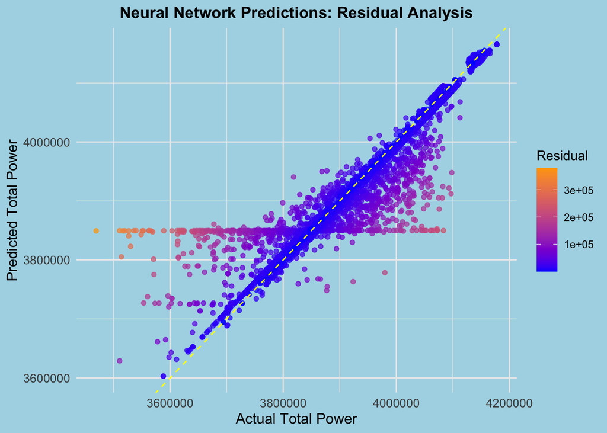

The results from the Neural Network learning algorithm were not overly convincing. The ggplot graph shows how much our total power estimates deviated from the actual total power. Assuming that the model was performing very well, we’d expect to see a high congregation of points on a line, with small residuals. Examining the graph, it’s clear that there is quite a bit of variation. In particular, the model seems to overestimate lower outputs and underestimates higher outputs. Although this could be the case for a multitude of reasons, I think it largely had to do with the number of neurons. The interactions between the features are complex and more neurons could have allowed the model to weigh more information. On the other hand, it is worth recognizing that there is a cohort of points that had predicted values that aligned with the actual values. This suggests that with the right tuning, a neural network model could work well for predicting total power output. In my neural network model, i’d argue that there is a little too much variance to confidently conclude that we can use machine learning to predict total power output consistently given coordinates and sams_metric. That being said, it’s clear that certain configurations inherently produce larger outputs, neural networks might not be the best way to capture the complexity of these relationships. It’s worth mentioning that Support Vector Machines and Smoothing Splines are other supervised learning algorithms that are worth exploring with this wave-farm data set, especially given its applications to energy conservation.